# Omy_Klamath_quality_filtering

Kevin Olsen

2024-10-31

```r
library(tidyverse)
library(DiagrammeR)
library(adegenet)
library(knitr)
library(magrittr)
library(lme4)
library(spaa)
library(poppr)
library(splitstackshape)
```

Read in marker information with marker read depths and genotype calls for each sample. For each sample, the first marker (OmyR40319Pearse) is shifted into the A1 count column.

```r
marker_info<-read_csv("C:/Users/olsenk2/OneDrive - Oregon State University/Desktop/Omy_klamath/Jan_2024_analyses/GT-seq_genotyping_output/Omy_Klamath_marker_info.csv")

kable(head(marker_info))
```

| ind | marker | a1_count | a2_count | called_geno | a1_corr | a2_corr |
| --- | --- | --- | --- | --- | --- | --- |
| ./PT12_H12_OmyKlamath27_Negative.genos | NA | OmyR40319Pearse=0 | =0 | NA | NA | NA |
| ./PT12_H12_OmyKlamath27_Negative.genos | Chr28_11607954 | G=0 | A=0 | NA | 0 | 0 |
| ./PT12_H12_OmyKlamath27_Negative.genos | Chr28_11625241 | A=0 | G=0 | NA | 0 | 0 |
| ./PT12_H12_OmyKlamath27_Negative.genos | Chr28_11632591 | G=0 | A=0 | NA | 0 | 0 |
| ./PT12_H12_OmyKlamath27_Negative.genos | Chr28_11658853 | A=0 | C=0 | NA | 0 | 0 |
| ./PT12_H12_OmyKlamath27_Negative.genos | Chr28_11667578 | T=0 | C=0 | NA | 0 | 0 |

Fix this by removing rows where A1 count is “OmyR40319Pearse=0”. Remove nucleotide letters and make allele 1 & 2 counts numeric. Remove “./” and “.genos” from sample names.

```r
marker_info %<>%
  filter(! a1_count == "OmyR40319Pearse=0")

marker_info %<>%
  mutate(a1_count =  as.numeric(substr(a1_count, 3, nchar(a1_count)))) %>%
  mutate(a2_count =  as.numeric(substr(a2_count, 3, nchar(a2_count)))) %>%
  mutate(ind = str_remove(ind, "^\\./")) %>%
  mutate(ind = str_remove(ind, "\\.genos"))
```

Read in GT-seq genotype dataframe.

```r
genos_0.1 <- read_csv("C:/Users/olsenk2/OneDrive - Oregon State University/Desktop/Omy_klamath/Jan_2024_analyses/GT-seq_genotyping_output/Omykiss_klamath_Jan_2024_GTs_0.1.csv")

kable(genos_0.1[1:5, 1:7])
```

| Sample | Raw Reads | On-Target Reads | %On-Target | %GT | IFI | …7 |
| --- | --- | --- | --- | --- | --- | --- |
| PT12_H12_OmyKlamath27_Negative | 411895 | 20 | 0.00 | 0.00 | 0.00 | 00 |
| PT21_A01_OmyKlamath15_OmyJC19WLMR_0366 | 283536 | 21418 | 7.55 | 75.00 | 0.08 | 00 |
| PT21_A01_OmyKlamath30_OmyAC16UKLA_0001 | 443290 | 178 | 0.04 | 0.26 | 0.00 | 00 |
| PT21_A01_OmyKlamath32_OmyJC19SPRR_0348 | 288398 | 8466 | 2.94 | 50.26 | 0.11 | 00 |
| PT21_A02_OmyKlamath15_OmyJC19WLMR_0374 | 272080 | 9954 | 3.66 | 58.42 | 0.12 | 00 |

Remove blank column (7th column). Create new column and identify positive and negative controls from sample name. Create new column and identify “empty” fastqs from sample name.

```r
genos_0.1<-genos_0.1[, -7]

genos_0.1 %<>%
  mutate(control = case_when(str_detect(Sample, "positive") ~ "positive",
                             str_detect(Sample, "Positive") ~ "positive",
                             str_detect(Sample, "Negative") ~ "negative",
                             str_detect(Sample, "negative") ~ "negative",
                             TRUE ~ "sample")) %>%
  mutate(empty = case_when(str_detect(Sample, "Empty") ~ "empty",
                           str_detect(Sample, "empty") ~"empty",
                           TRUE ~ "full"))
```

51 negative controls.

```r
kable(table(genos_0.1$control))
```

| Var1 | Freq |
| --- | --- |
| negative | 51 |
| sample | 4506 |

68 empty FASTQ files.

```r
kable(table(genos_0.1$empty))
```

| Var1 | Freq |
| --- | --- |
| empty | 68 |
| full | 4489 |

4,557 FASTQ files total. 390 markers and one sex marker in panel.

```r
dim(genos_0.1)
```

```
## [1] 4557  399
```

Remove “empty” FASTQ files and the column identifying them.

```r
genos_0.1 %<>%
  filter(empty == "full") %>%
  select(-empty)
```

Clean up sample name in new column “sample_simple”. Relocate sample names and adapters.

```r
genos_0.1 %<>%
  mutate(adapter = str_extract(Sample, "[ATCG]{6}-[ATCG]{6}")) %>%
  mutate(sample_simple = str_extract(Sample, "[:upper:][:lower:]{2}[AJCU][RC]\\d{2}\\w{4}_\\d{4}")) %>%
  relocate(Sample, sample_simple, adapter)
```

Distribution of On Target reads in samples and negative controls.

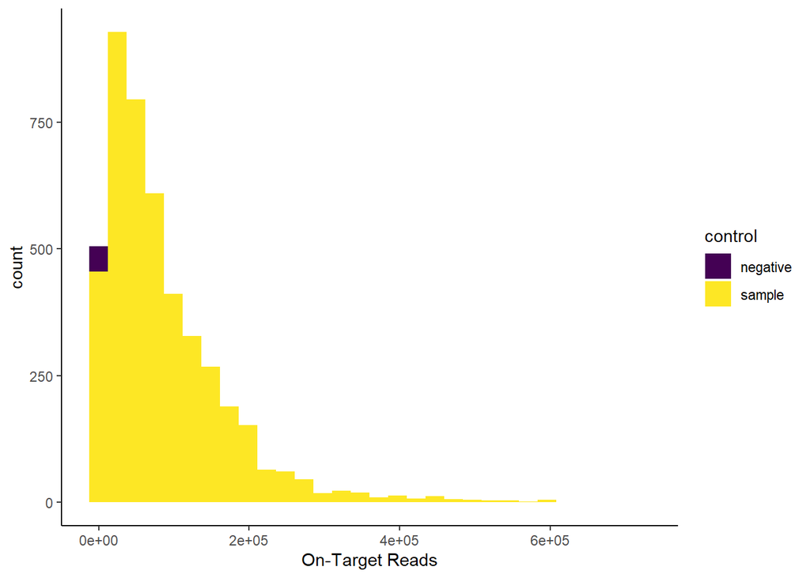

```r
ggplot()+geom_histogram(data = genos_0.1, aes(x = `On-Target Reads`, fill= control)) + theme_classic()+scale_fill_viridis_d()
```

Proportion of reads On Target.

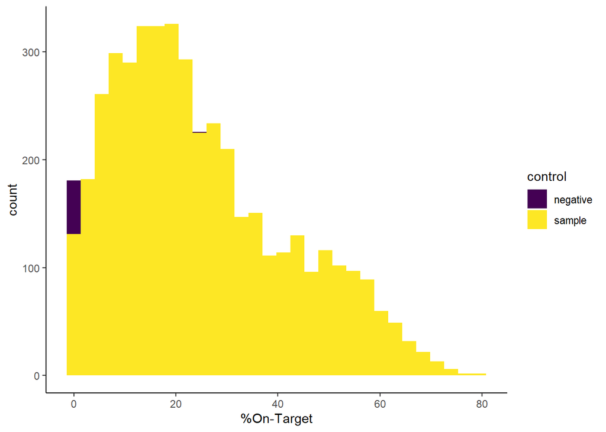

```r
ggplot()+geom_histogram(data = genos_0.1, aes(x = `%On-Target`, fill= control)) + theme_classic()+scale_fill_viridis_d()
```

50 negative controls look good with very few number and proportion of On Target reads. In one negative control (PT26_H12_OmyKlamath1_Negative) 24.2% of reads are On Target, suggesting there may have been some contamination in this neg control

Remove negative controls and the column identifying them.

```r
genos_0.11 <- genos_0.1 %>%
  filter(control == "sample") %>%
  select(-control)
```

Identify replicate positive controls and calculate how similar their genotype calls are (i.e., concordance).

```r
genos_0.11 %<>%
  group_by(sample_simple) %>%
  slice_max(order_by = `On-Target Reads`, n = 2)

dups <- genos_0.11[genos_0.11$sample_simple %in% genos_0.11$sample_simple[duplicated(genos_0.11$sample_simple)],]
dups <- dups[order(dups$sample_simple),]

kable(dups[1:10, 2:8])
```

| sample_simple | adapter | Raw Reads | On-Target Reads | %On-Target | %GT | IFI |
| --- | --- | --- | --- | --- | --- | --- |
| OmyAC09SSNT_0068 | NA | 658987 | 273963 | 41.57 | 97.45 | 0.23 |
| OmyAC09SSNT_0068 | NA | 654851 | 223871 | 34.19 | 97.45 | 0.15 |
| OmyAC14SSNT_0008 | NA | 792023 | 323456 | 40.84 | 97.19 | 0.40 |
| OmyAC14SSNT_0008 | NA | 594269 | 235650 | 39.65 | 97.45 | 0.37 |
| OmyAC19KLAR_0050 | NA | 661635 | 250871 | 37.92 | 90.56 | 0.27 |
| OmyAC19KLAR_0050 | NA | 765693 | 242617 | 31.69 | 95.41 | 0.26 |
| OmyJC16TRIR_0001 | NA | 327700 | 82596 | 25.20 | 98.47 | 0.17 |
| OmyJC16TRIR_0001 | NA | 211401 | 67989 | 32.16 | 97.96 | 0.13 |
| OmyJC16TRIR_0002 | NA | 576652 | 299915 | 52.01 | 97.96 | 0.15 |
| OmyJC16TRIR_0002 | NA | 242715 | 79060 | 32.57 | 97.70 | 0.11 |

112 replicate pairs in the dataset. Grab the genotypes. Calculate concordance with a nested for loop. Plot concordance.

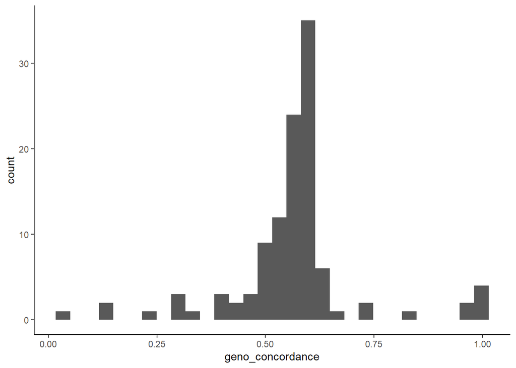

```r
dups_genos <- dups[,9:ncol(dups)]

rep_info <- matrix(ncol=ncol(dups_genos), nrow=nrow(dups_genos)/2)
colnames(rep_info) <- colnames(dups_genos)
for (j in 1:(nrow(dups_genos)/2)) {
  for (i in 1:ncol(dups_genos)) {
    rep_info[j,i] <- sum(dups_genos[(j*2)-1,i]==dups_genos[(j*2),i])
  }
}

geno_concordance <- as.data.frame(as.matrix(rep_info)) %>%
  rowMeans()
rep_data <- as.data.frame(cbind(dups[c(1:length(geno_concordance))*2,1], geno_concordance))

ggplot(data=rep_data)+geom_histogram(aes(x=geno_concordance))+theme_classic()
```

Proportion of calls that are the same in replicate samples ranges from 0.03 - 0.99. Look at which samples have less than 0.5 concordance.

```r
lowconcordance<-rep_data[which(rep_data$geno_concordance < 0.5), ]

kable(lowconcordance[, ], row.names = FALSE)
```

| Sample | geno_concordance |
| --- | --- |
| PT28_A04_OmySalmonKlamath_UCD_P1_OmyJC16TRIR_0024 | 0.4833760 |
| PT28_B04_OmySalmonKlamath_UCD_P1_OmyJC16TRIR_0025 | 0.3938619 |
| PT28_A05_OmySalmonKlamath_UCD_P1_OmyJC16TRIR_0032 | 0.4705882 |
| PT28_B05_OmySalmonKlamath_UCD_P1_OmyJC16TRIR_0033 | 0.4936061 |
| PT28_A06_OmySalmonKlamath_UCD_P1_OmyJC16TRIR_0039 | 0.1329923 |
| PT28_B06_OmySalmonKlamath_UCD_P1_OmyJC16TRIR_0040 | 0.3069054 |
| PT28_C06_OmySalmonKlamath_UCD_P1_OmyJC16TRIR_0041 | 0.4398977 |
| PT28_B07_OmySalmonKlamath_UCD_P1_OmyJC16TRIR_0048 | 0.4808184 |
| PT28_E07_OmySalmonKlamath_UCD_P1_OmyJC16TRIR_0051 | 0.4936061 |
| PT28_A08_OmySalmonKlamath_UCD_P1_OmyJC16TRIR_0055 | 0.4987212 |
| PT33_B08_OmySFTrinity_UCD_P1_OmyJC16TRIR_0056 | 0.1304348 |
| PT28_G08_OmySalmonKlamath_UCD_P1_OmyJC16TRIR_0061 | 0.3120205 |
| PT28_C09_OmySalmonKlamath_UCD_P1_OmyJC16TRIR_0065 | 0.4961637 |
| PT33_G09_OmySFTrinity_UCD_P1_OmyJC16TRIR_0069 | 0.4322251 |
| PT28_B10_OmySalmonKlamath_UCD_P1_OmyJC16TRIR_0072 | 0.4833760 |
| PT28_C10_OmySalmonKlamath_UCD_P1_OmyJC16TRIR_0073 | 0.2966752 |
| PT28_F10_OmySalmonKlamath_UCD_P1_OmyJC16TRIR_0076 | 0.4757033 |
| PT28_A11_OmySalmonKlamath_UCD_P1_OmyJC16TRIR_0079 | 0.4092072 |
| PT28_B11_OmySalmonKlamath_UCD_P1_OmyJC16TRIR_0080 | 0.4961637 |
| PT28_F11_OmySalmonKlamath_UCD_P1_OmyJC16TRIR_0084 | 0.2404092 |
| PT28_D12_OmySalmonKlamath_UCD_P1_OmyJC16TRIR_0090 | 0.3989770 |
| PT28_E12_OmySalmonKlamath_UCD_P1_OmyJC16TRIR_0091 | 0.0332481 |
| PT33_B02_OmyKlamath26_OmyJC19KLAR_0037 | 0.3196931 |

Of the 23 duplicate pairs with less than 0.5 concordance, 22 of them come from the same sampling pool (OmyJC16TRIR).  
This suggests poor genotyping success or contamination may be present here.

Write a new dataset (0.2) by choosing the samples within replicates and keeping the one with the highest genotyping success.

```r
genos_0.2 <- genos_0.11 %>%
  group_by(sample_simple) %>%
  filter(`On-Target Reads` == max(`On-Target Reads`))
```

Dataset now has 4,295 unique samples genotyped at 390 loci and one sex marker.

```r
dim(genos_0.2)
```

```
## [1] 4295  399
```

```r
length(unique(genos_0.2$sample_simple))
```

```
## [1] 4295
```

Compare sample names in genotype dataframe to sample names in metadata. Read in project metadata.

```r
meta<-read.csv("C:/Users/olsenk2/OneDrive - Oregon State University/Desktop/Omy_klamath/klamath_omykiss_sampling_metadata.csv", header = T)
```

Idenitfy sample names in the metadata that are not present in the genotype dataframe. 395 samples in metadatae file that are missing from genos_0.2.  
Of which 194 were from Cape Cod Stock (72) or Crooked Creek which were removed before genotyping because they are triploid.

```r
in_meta_but_missing_genos_0.2<-meta[which(!meta$SFGL_ID %in% genos_0.2$sample_simple), ]
```

Identify samples in genotype dataframe that are not present in metadata file. 15 samples are in genotype dataframe that aren’t in metadata file.

```r
in_genos_0.2_but_missing_meta<-genos_0.2[which(!genos_0.2$sample_simple %in% meta$SFGL_ID), ]
```

Remove samples from genotype dataframe that aren’t in project metadata file.

```r
genos_0.2 %<>%
  filter(! sample_simple  %in% in_genos_0.2_but_missing_meta$sample_simple)
```

Filter marker info file to remove empty FASTQ files, negative controls, and duplicates.

```r
marker_info %<>%
  filter(ind %in% genos_0.2$Sample)
```

Look at genotyping success of the sex marker.

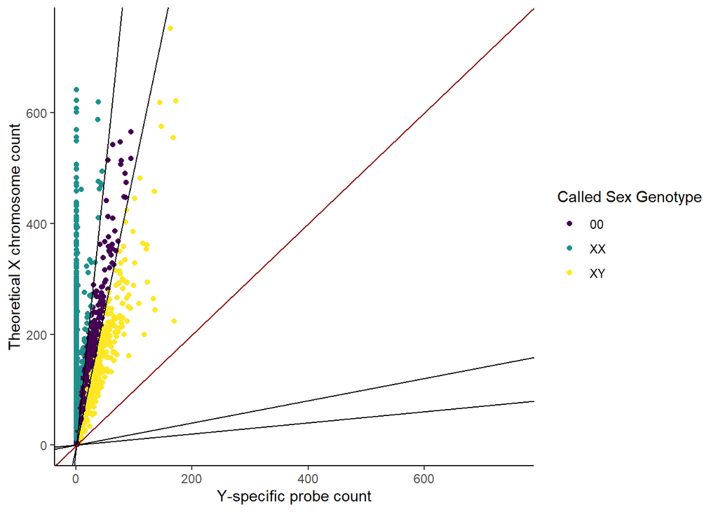

```r
sex_marker_info <- marker_info %>%
  filter(str_detect(marker, "SEXY")) %>%
  mutate(called_geno = replace_na(called_geno, "00")) %>%
  mutate(called_geno = case_when(called_geno == "A1HOM" ~ "XX",
                                 called_geno == "HET" ~ "XY",
                                 called_geno == "00" ~ "00"))

ggplot(data = sex_marker_info)+geom_point(aes(a2_count, a1_count, color = called_geno))+scale_colour_viridis_d(name = "Called Sex Genotype")+theme_classic()+xlab("Y-specific probe count")+ylab("Theoretical X chromosome count")+geom_abline(aes(intercept = 0, slope = 0.1))+geom_abline(aes(intercept = 0, slope = 5))+geom_abline(aes(intercept = 0, slope = 10))+geom_abline(aes(intercept = 0, slope = 0.2))+xlim(0,max(c(sex_marker_info$a1_count, sex_marker_info$a2_count)))+ylim(0,max(c(sex_marker_info$a1_count, sex_marker_info$a2_count)))+geom_abline(aes(intercept = 0, slope = 1), color = "darkred")
```

Sex marker is biased towards X counts (which is typical for the O. mykiss sex marker).  
Lets correct this.

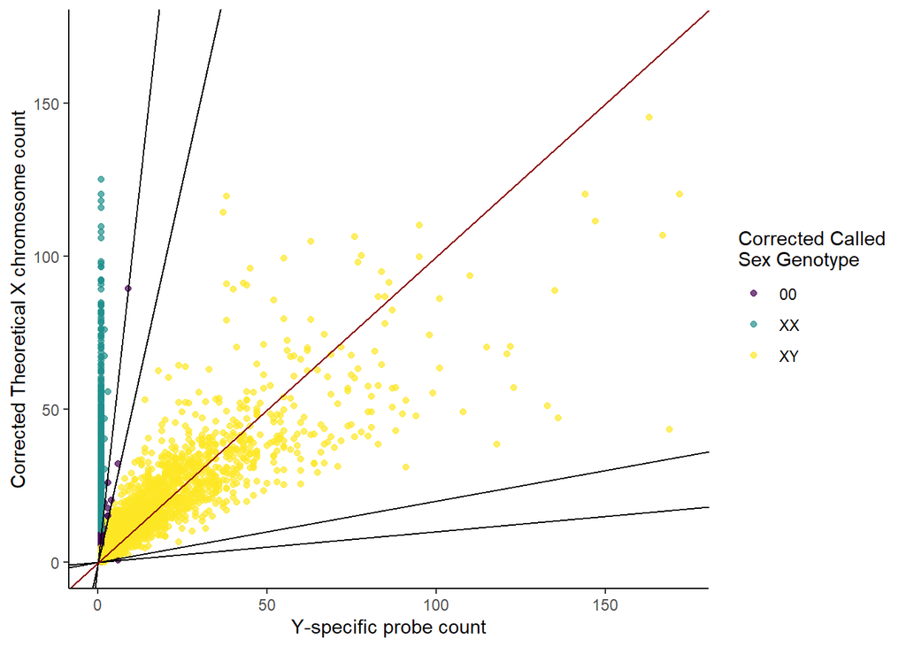

```r
sex_marker_info$sample <- str_extract(sex_marker_info$ind, "[:upper:][:lower:]{2}[AJCU][RC]\\d{2}\\w{4}_\\d{4}")
sex_marker_info$adapter <- str_extract(sex_marker_info$ind, "[ATCG]{6}-[ATCG]{6}")

sex_marker_info %<>%
  left_join(dplyr::select(genos_0.2, sample_simple, adapter, `On-Target Reads`), by = c("sample" = "sample_simple" , "adapter" = "adapter"))


Xmale_proportion_error <- sex_marker_info %>%
  filter(a2_count > 1) %>% #this value is set to 1 if the actual count is zero in the omysexscript, so here we're are eliminating all individuals where it woulbe extremely unlikely that they are males
  summarise(Xmale_proportion = mean(a2_count/`On-Target Reads`, na.rm = TRUE))

sex_marker_info %<>%
  mutate(XY_count_estimate = Xmale_proportion_error[[1]]*`On-Target Reads`) %>%
  mutate(corrected_ratio = XY_count_estimate/a2_count) %>%
  mutate(corrected_sex_genotype = case_when(corrected_ratio > 10 ~ "XX",
                                            corrected_ratio <= 0.1 ~ "XY",
                                            corrected_ratio <= 0.2 ~ "00",
                                            corrected_ratio <= 5 ~ "XY",
                                            TRUE ~ "00"
  ))

ggplot(data = sex_marker_info)+geom_point(aes(a2_count, XY_count_estimate, color = corrected_sex_genotype), alpha = 0.7)+scale_colour_viridis_d(name = "Corrected Called\nSex Genotype")+theme_classic()+xlab("Y-specific probe count")+ylab("Corrected Theoretical X chromosome count")+geom_abline(aes(intercept = 0, slope = 0.1))+geom_abline(aes(intercept = 0, slope = 5))+geom_abline(aes(intercept = 0, slope = 10))+geom_abline(aes(intercept = 0, slope = 0.2))+xlim(0,max(c(sex_marker_info$XY_count_estimate, sex_marker_info$a2_count)))+ylim(0,max(c(sex_marker_info$XY_count_estimate, sex_marker_info$a2_count)))+geom_abline(aes(intercept = 0, slope = 1), color = "darkred")
```

Correction was successful. Now corrrect in the genotype dataframe.

```r
genos_0.2 %<>%
  left_join(select(sex_marker_info, sample, corrected_sex_genotype), by = c("sample_simple"="sample")) %>%
  mutate(OmyY1_2SEXY = corrected_sex_genotype) %>%
  select(-corrected_sex_genotype)
```

Now we filter the dataset based on genotyping quality. We will iteratively filter given marker and sample call rates, and IFI scores. Visualize IFI scores, individual call rates, and locus call rates.

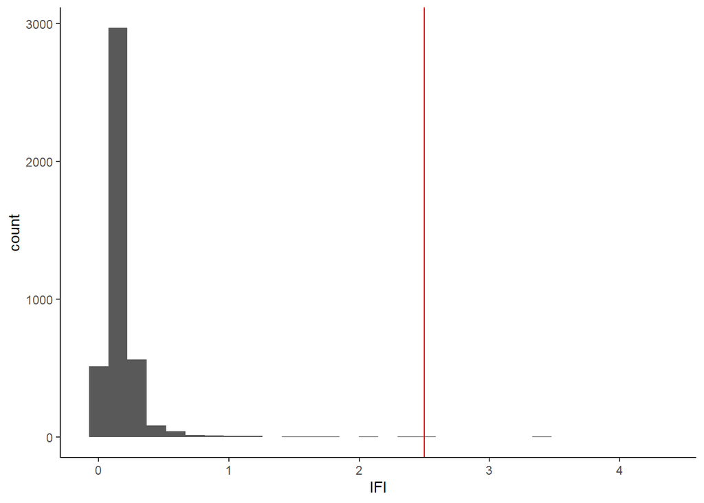

```r
ggplot(genos_0.2)+geom_histogram(aes(x=IFI))+geom_vline(aes(xintercept= 2.5), color="red")+theme_classic()
```

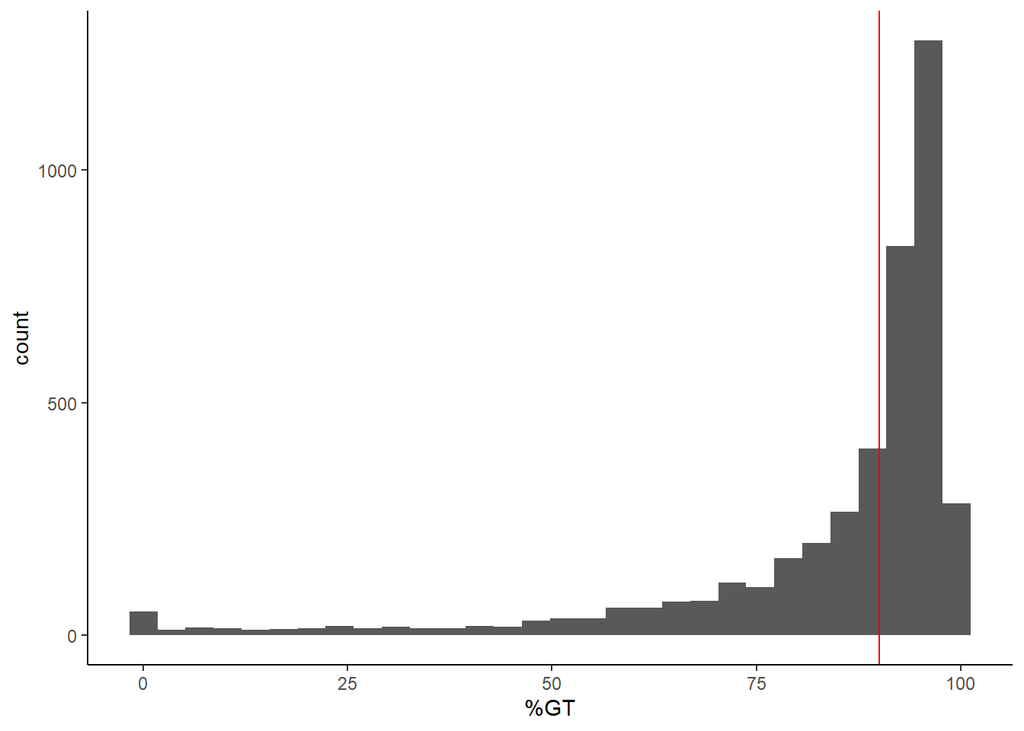

```r
ggplot(genos_0.2)+geom_histogram(aes(x=`%GT`))+geom_vline(aes(xintercept= 90), color="red")+theme_classic()
```

Calculate locus call rates.

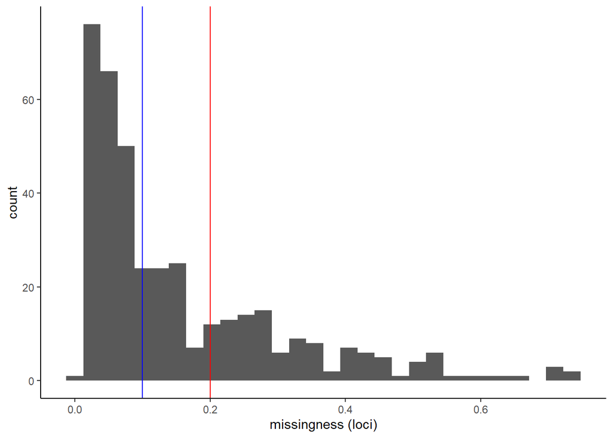

```r
missingness <- (colSums(genos_0.2[,c(9:ncol(genos_0.2))] == "00" | genos_0.2[,c(8:(ncol(genos_0.2)-1))] == "0"))/nrow(genos_0.2)
missing <- as.data.frame(missingness)
missing$marker <- row.names(missing)

ggplot(missing) + geom_histogram(aes(x=missingness))+geom_vline(aes(xintercept= 0.2), color="red")+geom_vline(aes(xintercept= 0.1), color="blue")+theme_classic()+xlab("missingness (loci)")
```

629 samples have call rates below 70%

```r
kable(genos_0.2 %>%
        filter(`%GT` < 70) %>%
        select(2,4:7), caption = "Individuals with high missingess (>30% missing data)")
```

Individuals with high missingess (>30% missing data)

| sample_simple | Raw Reads | On-Target Reads | %On-Target | %GT |
| --- | --- | --- | --- | --- |
| OmyAC02TRIR_0018 | 300339 | 230 | 0.08 | 0.00 |
| OmyAC02TRIR_0019 | 447627 | 1241 | 0.28 | 6.89 |
| OmyAC16KLAR_0008 | 1102 | 194 | 17.60 | 0.00 |
| OmyAC16UKLA_0001 | 443290 | 178 | 0.04 | 0.26 |
| OmyAC17FOSC_0010 | 120651 | 7841 | 6.50 | 63.27 |
| OmyAC17UKLA_0001 | 316047 | 358 | 0.11 | 1.53 |
| OmyAC17UKLA_0005 | 415141 | 167 | 0.04 | 0.26 |
| OmyAC17UKLA_0007 | 400753 | 3282 | 0.82 | 23.47 |
| OmyAC17UKLA_0008 | 325954 | 153 | 0.05 | 0.26 |
| OmyAC17UKLA_0009 | 344771 | 4572 | 1.33 | 30.87 |
| OmyAC17UKLA_0012 | 458422 | 195 | 0.04 | 0.00 |
| OmyAC17UKLA_0020 | 495558 | 4588 | 0.93 | 30.87 |
| OmyAC17UKLA_0024 | 331921 | 431 | 0.13 | 1.02 |
| OmyAC17UKLA_0025 | 347805 | 10152 | 2.92 | 41.58 |
| OmyAC17UKLA_0026 | 997 | 246 | 24.67 | 0.26 |
| OmyAC17UKLA_0041 | 292894 | 19113 | 6.53 | 69.13 |
| OmyAC18KLAR_0064 | 36 | 7 | 19.44 | 0.00 |
| OmyAC18KLAR_0065 | 24 | 9 | 37.50 | 0.00 |
| OmyAC18KLAR_0066 | 187 | 64 | 34.22 | 0.00 |
| OmyAC18KLAR_0067 | 14 | 6 | 42.86 | 0.00 |
| OmyAC18SPRR_0001 | 425899 | 14933 | 3.51 | 66.84 |
| OmyAC18SPRR_0002 | 236159 | 11655 | 4.94 | 56.12 |
| OmyAC18UKLA_0001 | 366590 | 2069 | 0.56 | 15.05 |
| OmyAC18UKLA_0007 | 611175 | 724 | 0.12 | 3.83 |
| OmyAC18WLMR_0004 | 457028 | 464 | 0.10 | 1.28 |
| OmyAC18WLMR_0005 | 513546 | 1533 | 0.30 | 7.65 |
| OmyAC19KLAR_0071 | 1463 | 48 | 3.28 | 0.00 |
| OmyAC19SPRR_0009 | 207997 | 16088 | 7.73 | 67.09 |
| OmyAC19SPRR_0011 | 195273 | 26671 | 13.66 | 64.54 |
| OmyAC19SPRR_0012 | 230731 | 10972 | 4.76 | 56.89 |

[output cut: 599 more lines]

Remove samples with call rates below 70%.

```r
genos_0.3 <- genos_0.2 %>%
  filter(`%GT` > 70)
```

Recalculate marker call rates. Now that poorly genotyped samples have been removed.

```r
missingness2 <- (colSums(genos_0.3[,c(9:(ncol(genos_0.3)))] == "00" | genos_0.3[,c(9:(ncol(genos_0.3)))] == "0"))/nrow(genos_0.3)
missing2 <- as.data.frame(missingness2)
missing2$marker <- row.names(missing2)

kable(missing2[1:10, ], row.names =
        FALSE, col.names = c("Prop of samples missing call", "marker"))
```

| Prop of samples missing call | marker |
| --- | --- |
| 0.0104081 | Chr28_11607954 |
| 0.7176116 | Chr28_11625241 |
| 0.0002739 | Chr28_11632591 |
| 0.0000000 | Chr28_11658853 |
| 0.1059984 | Chr28_11667578 |
| 0.5351958 | Chr28_11671116 |
| 0.0851821 | Chr28_11676622 |
| 0.0851821 | Chr28_11683204 |
| 0.0073952 | Chr28_11702210 |
| 0.0062996 | Chr28_11773194 |

9 markers have call rates below 50% “Chr28_11625241” “Chr28_11671116” “OMS00074” “Omy_RAD2277-7” “Omy_RAD43117-55” “Omy_gsdf-291” “Omy_impa1-55” “Omy_ndk-152” “Omy_u09-61.043”

```r
very_bad_markers <- missing2[which(missing2$missingness2 > 0.5), ]
```

Remove 9 markers with low call rates.

```r
genos_0.3 %<>%
  dplyr::select(-one_of(very_bad_markers$marker))
```

Recalculate IFI scores.

```r
IFI <- marker_info %>%
  filter(marker %in% colnames(genos_0.3)) %>%
  group_by(ind) %>%
  summarize(back_count = sum(a1_count[called_geno == "A2HOM"], na.rm = TRUE)
            + sum(a2_count[called_geno == "A1HOM"], na.rm = TRUE)
            + sum(a1_count[is.na(called_geno) == TRUE & ((a1_count + a2_count)>=10) & (a2_count > a1_count)], na.rm = TRUE )
            + sum(a2_count[is.na(called_geno) == TRUE & ((a1_count + a2_count)>=10) & (a1_count > a2_count)], na.rm = TRUE ),

            hom_ct = sum(a1_count[called_geno == "A1HOM"], na.rm = TRUE)
            + sum(a2_count[called_geno == "A2HOM"], na.rm = TRUE)
            + sum(a2_count[is.na(called_geno) == TRUE & ((a1_count + a2_count)>=10) & (a2_count > a1_count)], na.rm = TRUE )
            + sum(a1_count[is.na(called_geno) == TRUE & ((a1_count + a2_count)>=10) & (a1_count > a2_count)], na.rm = TRUE ),

            ifi2 = (back_count/hom_ct)*100)

IFI$sample <- str_extract(IFI$ind, "[:upper:][:lower:]{2}[AJCU][RC]\\d{2}\\w{4}_\\d{4}")
IFI$adapter <- str_extract(IFI$ind, "[ATCG]{6}-[ATCG]{6}")

genos_0.3 <- genos_0.3 %>%
  left_join(select(IFI, sample, adapter, ifi2), by = c("sample_simple" = "sample", "adapter" = "adapter")) %>%
  mutate(IFI = ifi2) %>%
  select(-one_of("ifi2"))

print(paste(length(which(genos_0.3$IFI > 10)), caption = "Extreme High IFI (>10) samples (low confidence barcodes)"))
```

```
## [1] "0 Extreme High IFI (>10) samples (low confidence barcodes)"
```

Recalculate sample call rates. Identify samples with call rates below 90%.

```r
genos_0.3 %<>%
  rowwise %>%
  mutate(`%GT` = 100*(1-sum((cur_data() == "00"), na.rm = TRUE)/(ncol(.)-8))) %>%
  ungroup() #always ungroup after rowwise

print(paste(length(which(genos_0.3$`%GT` < 90)), caption = "Individuals with high missingess (>10% missing data)"))
```

```
## [1] "915 Individuals with high missingess (>10% missing data)"
```

Remove samples with call rates below 90%

```r
genos_0.4 <- genos_0.3 %>%
  filter(`%GT` > 90)
```

Recalculate marker call rates after removing poorly genotyped samples.

```r
missingness3 <- (colSums(genos_0.4[,c(9:(ncol(genos_0.4)))] == "00" | genos_0.4[,c(9:(ncol(genos_0.4)))] == "0"))/nrow(genos_0.4)
missing3 <- as.data.frame(missingness3)
missing3$marker <- row.names(missing3)

#then remove these markers
# collect bad markers
bad_markers <- missing3[which(missing3$missingness3 > 0.2), ]
print(paste(length(bad_markers$marker), "markers with > 20% missing data"))
```

```
## [1] "30 markers with > 20% missing data"
```

30 markers have call rates below 80%.

```r
kable(bad_markers, row.names = FALSE, col.names = c("Proportion of samples missing call", "marker"))
```

| Proportion of samples missing call | marker |
| --- | --- |
| 0.2160088 | M09AAC.055 |
| 0.2119883 | OMS00018 |
| 0.2624269 | OMS00056 |
| 0.3570906 | OMS00071 |
| 0.3432018 | OMS00072 |
| 0.3176170 | OMS00087 |
| 0.3230994 | OMS00173 |
| 0.3055556 | Omy_104569-114 |
| 0.3165205 | Omy_109894-185 |
| 0.2580409 | Omy_112301-202 |
| 0.2613304 | Omy_117286-374 |
| 0.3830409 | Omy_118205-116 |
| 0.2825292 | Omy_128996-481 |
| 0.2627924 | Omy_GHSR-121 |
| 0.2638889 | Omy_LDHB-2_e5 |
| 0.3848684 | Omy_MYC_2 |
| 0.2309942 | Omy_Ogo4-212 |
| 0.3490497 | Omy_RAD14541-72 |
| 0.2616959 | Omy_RAD1751-18 |
| 0.3892544 | Omy_RAD17632-23 |
| 0.2379386 | Omy_RAD23354-66 |
| 0.3183480 | Omy_RAD23577-43 |
| 0.3088450 | Omy_RAD25907-57 |
| 0.3439327 | Omy_RAD26080-69 |
| 0.3442982 | Omy_RAD30230-25 |
| 0.2350146 | Omy_RAD38406-19 |
| 0.3494152 | Omy_RAD92485-64 |
| 0.3146930 | Omy_SECC22b-88 |
| 0.3739035 | Omy_UBA3b |
| 0.3527047 | Omy_hsp90BA-193 |

Remove markers with call rates below 80%

```r
genos_0.4 %<>%
  dplyr::select(-one_of(bad_markers$marker))
```

Recalculate IFI scores.

```r
IFI <- marker_info %>%
  filter(marker %in% colnames(genos_0.4)) %>%
  group_by(ind) %>%
  summarize(back_count = sum(a1_count[called_geno == "A2HOM"], na.rm = TRUE)
            + sum(a2_count[called_geno == "A1HOM"], na.rm = TRUE)
            + sum(a1_count[is.na(called_geno) == TRUE & ((a1_count + a2_count)>=10) & (a2_count > a1_count)], na.rm = TRUE )
            + sum(a2_count[is.na(called_geno) == TRUE & ((a1_count + a2_count)>=10) & (a1_count > a2_count)], na.rm = TRUE ),

            hom_ct = sum(a1_count[called_geno == "A1HOM"], na.rm = TRUE)
            + sum(a2_count[called_geno == "A2HOM"], na.rm = TRUE)
            + sum(a2_count[is.na(called_geno) == TRUE & ((a1_count + a2_count)>=10) & (a2_count > a1_count)], na.rm = TRUE )
            + sum(a1_count[is.na(called_geno) == TRUE & ((a1_count + a2_count)>=10) & (a1_count > a2_count)], na.rm = TRUE ),

            ifi2 = (back_count/hom_ct)*100)

IFI$sample <- str_extract(IFI$ind, "[:upper:][:lower:]{2}[AJCU][RC]\\d{2}\\w{4}_\\d{4}")
IFI$adapter <- str_extract(IFI$ind, "[ATCG]{6}-[ATCG]{6}")


genos_0.4 <- genos_0.4 %>%
  left_join(select(IFI, sample, adapter, ifi2), by = c("sample_simple" = "sample", "adapter" = "adapter")) %>%
  mutate(IFI = ifi2) %>%
  select(-one_of("ifi2"))

print(paste(length(which(genos_0.4$IFI > 2.5)), "High IFI (>2.5) samples (low confidence barcodes)"))
```

```
## [1] "7 High IFI (>2.5) samples (low confidence barcodes)"
```

```r
high_IFI<-genos_0.4[which(genos_0.4$IFI > 2.5), 2:8]

kable(high_IFI)
```

| sample_simple | adapter | Raw Reads | On-Target Reads | %On-Target | %GT | IFI |
| --- | --- | --- | --- | --- | --- | --- |
| OmyJC19WOOR_0011 | NA | 361648 | 57476 | 15.89 | 90.31414 | 2.903912 |
| OmyJC19WOOR_0012 | NA | 286434 | 57734 | 20.16 | 91.09948 | 2.857279 |
| OmyJC19WOOR_0014 | NA | 384881 | 73049 | 18.98 | 92.67016 | 2.553486 |
| OmyJC19WOOR_0016 | NA | 485763 | 107939 | 22.22 | 91.09948 | 3.015369 |
| OmyJC19WOOR_0020 | NA | 305185 | 81268 | 26.63 | 90.05236 | 3.268169 |
| OmyJC19WOOR_0023 | NA | 319592 | 77843 | 24.36 | 91.36126 | 2.643971 |
| OmyJC19WOOR_0037 | NA | 353231 | 70954 | 20.09 | 90.57592 | 2.559098 |

Remove samples with IFI score greater than 2.5.

```r
genos_0.4 %<>%
  filter(IFI < 2.5)
```

Recalculate marker call rates.

```r
missingness3 <- (colSums(genos_0.4[,c(9:(ncol(genos_0.4)))] == "00" | genos_0.4[,c(9:(ncol(genos_0.4)))] == "0"))/nrow(genos_0.4)
missing3 <- as.data.frame(missingness3)
missing3$marker <- row.names(missing3)

dim(genos_0.4)
```

```
## [1] 2729  360
```

```r
range(missing3$missingness3)
```

```
## [1] 0.0000000 0.1975082
```

```r
range(genos_0.4$IFI)
```

```
## [1] 0.04137444 2.42463059
```

```r
range(genos_0.4$`%GT`)
```

```
## [1]  90.05236 100.00000
```

Now evaluate potentially paralogous markers. Subset markers with call rate between 80 - 90%

```r
miss0.1 <- missing3[missing3$missingness3 > 0.1,]
miss_mod <- miss0.1[miss0.1$missingness3 < 0.2, 2]
```

Get allele counts for all heterozygous calls. Calculate and plot A1 / A2 ratios for all heterozygote calls. Ideally you’d like to see 1 to 1 allele ratios.

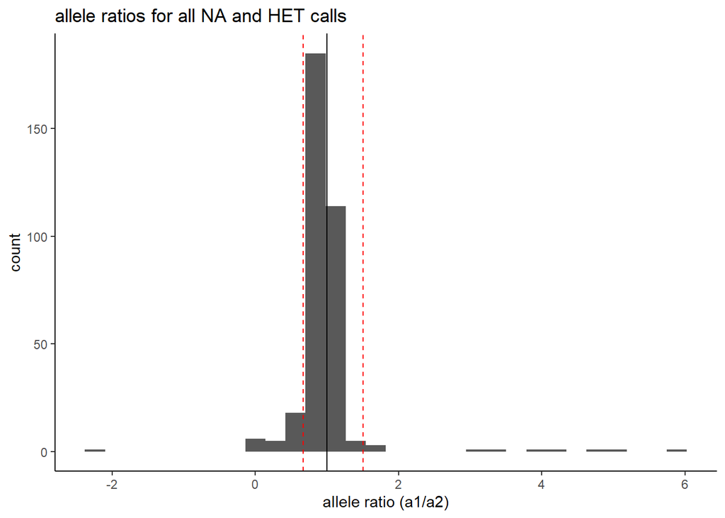

```r
hets <- filter(marker_info, called_geno == "HET" | is.na(called_geno))

models <- hets %>%
  filter(marker %in% colnames(genos_0.4)) %>%
  filter(is.na(a1_count) == FALSE & is.na(a2_count) == FALSE) %>%
  group_by(marker) %>%
  group_map(~ lm(a1_count ~ a2_count, data= .))


lms <- lapply(models, coef)
ggplot()+geom_histogram(aes(x = sapply(lms,`[`,2)))+theme_classic()+ggtitle("allele ratios for all NA and HET calls")+geom_vline(aes(xintercept = 1.5), color = "red", linetype = 2)+geom_vline(aes(xintercept = (2/3)), color = "red", linetype = 2)+xlab("allele ratio (a1/a2)")+geom_vline(aes(xintercept = 1), color = "black")
```

Identify potential paralogs with skewed A1 or A2 allele ratios. Duplication events and paralogs are common in Salmonids so SFGL checks thoroughly for associated marker issues.

```r
lms_anova <- lapply(models, summary)

paralog_possible <- which(abs(sapply(lms,`[`,2)) > 1.5) #bad because a positively skewed allele ratio
paralog_possible2 <- which(abs(sapply(lms,`[`,2)) < (2/3)) # bad because a negative skewed allele ratio

paralog_possible3 <- which(sapply(lms_anova, function(x) x$coefficients[,4][2])> 0.01) # bad because too much variance in allele ratio, even if mean ratio is 1

paralog_possible <- c(paralog_possible, paralog_possible2, paralog_possible3)
```

Make plots of Allele 1 and Allele2 counts with genotype calls to vissually inspect potential paraogs.

```r
plots <- marker_info %>%
  filter(marker %in% colnames(genos_0.4)) %>%
  filter(is.na(a1_count) == FALSE & is.na(a2_count) == FALSE) %>%
  group_by(marker) %>%
  do(plots=ggplot(data=.)+geom_point(aes(a1_count, a2_count, color = called_geno))+theme_classic()+geom_abline(aes(slope=1, intercept=0))+geom_abline(aes(slope = 10, intercept=0), color = "green")+geom_abline(aes(slope = 0.1, intercept=0), color = "red")+geom_abline(aes(slope = 0.2, intercept=0), color = "blue")+geom_abline(aes(slope = 5, intercept=0), color = "blue")+coord_equal(ratio=1)+geom_abline(slope = -1, intercept = 10)+ggtitle(unique(.$marker)))

#first add the missningness markers to the list to examine
mod_bad_plot_index <- which(plots$marker %in% miss_mod)
paralog_possible <- c(mod_bad_plot_index, paralog_possible)
```

Loop through the plots by changing the index until you have looked at all questionable markers.

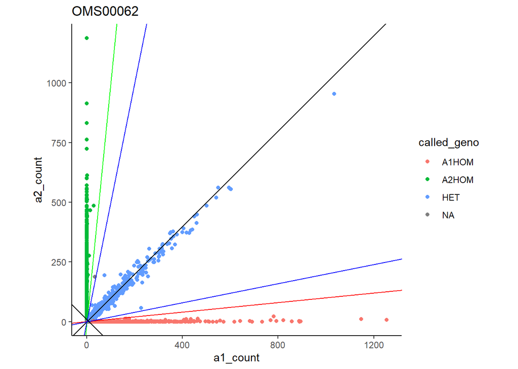

```r
plots$plots[[paralog_possible[1]]]
```

identified 5 markers as monomorphic or potential paralogs.

```r
to_filt <- c("Oki120255-113", "Omy_RAD30243-74", "Omy_RAD33122-47", "Omy_RAD35005-13", "Omy_cd59b-112")
```

Remove 5 monomorphic or paralogous markers.

```r
genos_0.5 <- genos_0.4 %>%
  dplyr::select(-one_of(to_filt))
```

At this point dataset has 2,729 individuals genotyped at 346 markers and a sex marker.

Evaluate potential duplicate sampling events using genetic distance in the R package poppr.

Remove “dots” from column names for formatting. Convert genotype dataframe to genind object.

```r
genind_1.0 <- genos_0.5
colnames(genind_1.0) <- gsub("\\.", "_", colnames(genos_0.5))

genind_1.0 <- as.matrix(genind_1.0[,c(9:ncol(genind_1.0))])

row.names(genind_1.0) <- genos_0.5$sample_simple
genind_1.0 <- df2genind(genind_1.0, sep = "", ploidy = 2, NA.char = "0")
```

Write genind object as genalex csv for reading into poppr.

```r
genind2genalex(genind_1.0, filename = "C:/Users/olsenk2/OneDrive - Oregon State University/Desktop/Omy_klamath/Jan_2024_analyses/reproducible/Omykiss_Klamath_with_duplicates_Jan_2024_analyses_genalex.csv")
```

Read in genalex csv into poppr.

```r
GT_poppr<-read.genalex("C:/Users/olsenk2/OneDrive - Oregon State University/Desktop/Omy_klamath/Jan_2024_analyses/reproducible/Omykiss_Klamath_with_duplicates_Jan_2024_analyses_genalex.csv")
```

Calculate pairwise genetic distance between all combinations of samples (except self-comparisons).

```r
GT_dist<-bitwise.dist(GT_poppr, percent = FALSE, mat = TRUE)
```

Make a dataframe with the pairwise distances.

```r
xy <- t(combn(colnames(GT_dist), 2))

GT_list<-data.frame(xy, dist=GT_dist[xy])

kable(GT_list[1:10, ], col.names = c("Sample_1", "Sample_2", "Genetic Distance"))
```

| Sample_1 | Sample_2 | Genetic Distance |
| --- | --- | --- |
| OmyAC02TRIR_0001 | OmyAC02TRIR_0002 | 116 |
| OmyAC02TRIR_0001 | OmyAC02TRIR_0003 | 138 |
| OmyAC02TRIR_0001 | OmyAC02TRIR_0004 | 127 |
| OmyAC02TRIR_0001 | OmyAC02TRIR_0005 | 136 |
| OmyAC02TRIR_0001 | OmyAC02TRIR_0006 | 134 |
| OmyAC02TRIR_0001 | OmyAC02TRIR_0007 | 132 |
| OmyAC02TRIR_0001 | OmyAC02TRIR_0008 | 146 |
| OmyAC02TRIR_0001 | OmyAC02TRIR_0009 | 141 |
| OmyAC02TRIR_0001 | OmyAC02TRIR_0010 | 139 |
| OmyAC02TRIR_0001 | OmyAC02TRIR_0011 | 137 |

Identify individuals with genetic distance less than 10.

```r
lowdist<-GT_list[which(GT_list$dist < 10), ]

kable(lowdist, col.names = c("Sample_1", "Sample_2", "Genetic Distance"))
```

|  | Sample_1 | Sample_2 | Genetic Distance |
| --- | --- | --- | --- |
| 1355957 | OmyJC00SPRR_0005 | OmyJC00SPRR_0006 | 2 |
| 1410041 | OmyJC00SPRR_0030 | OmyJC00SPRR_0040 | 0 |
| 3614039 | OmyUC19KLAR_0003 | OmyUC19KLAR_0040 | 1 |

SFGL often (but not always) uses relatedness estimates generated with the GUI coancestry to identify duplicates. Let’s see if the SFGL coancestry method identifies the same duplicate pairs as with genetic distance. Format the genotype dataframe for coancestry.

```r
replacedGT<-as.data.frame(genos_0.5[, c(9:(ncol(genos_0.5)-1))])

delim_gtypes <- replacedGT[, ] %>%
  mutate_all(funs(case_when(. == "AA" ~ "A/A",
                            . == "AT" ~ "A/T",
                            . == "AC" ~ "A/C",
                            . == "AG" ~ "A/G",
                            . == "TT" ~ "T/T",
                            . == "TA" ~ "T/A",
                            . == "TC" ~ "T/C",
                            . == "TG" ~ "T/G",
                            . == "CC" ~ "C/C",
                            . == "CA" ~ "C/A",
                            . == "CT" ~ "C/T",
                            . == "CG" ~ "C/G",
                            . == "GG" ~ "G/G",
                            . == "GA" ~ "G/A",
                            . == "GT" ~ "G/T",
                            . == "GC" ~ "G/C",
                            . == "--" ~ "-/-",
                            . == "A-" ~ "A/-",
                            . == "T-" ~ "T/-",
                            . == "C-" ~ "C/-",
                            . == "G-" ~ "G/-",
                            . == "-A" ~ "-/A",
                            . == "-T" ~ "-/T",
                            . == "-C" ~ "-/C",
                            . == "-G" ~ "-/G",
                            . == "00" ~ "0/0",
                            . == "0" ~ "0/0"
  )))


vrtnames<-c(colnames(delim_gtypes))

##split genotypes into 2 alleles##
dfspltgeno<-as.data.frame(cSplit(delim_gtypes, splitCols = vrtnames, sep = "/", type.convert = FALSE))

coancestrylbls<-data.frame(c(genos_0.5$sample_simple))

colnames(coancestrylbls)<-c("Ind")

##coancestry has a character limit for sample names so remove "Omy" from sample name##
coancestrylbls %<>%
  mutate(Ind = substr(Ind, 4, 16))

rownames(dfspltgeno)<-as.character(coancestrylbls$Ind)

##replace nucleotides with numeric values for coancestry##
##A = 1; T = 2; C = 3; G = 4; - = 5 ###

dfspltgeno %<>%
  mutate_all(funs(case_when(. == "A" ~ 1,
                            . == "T" ~ 2,
                            . == "C" ~ 3,
                            . == "G" ~ 4,
                            . == "-" ~ 5,
                            . == "0" ~ 0,
  )))

##write the coancestry input as a text file##
write.table(dfspltgeno, file = "C:/Users/olsenk2/OneDrive - Oregon State University/Desktop/Omy_klamath/Jan_2024_analyses/reproducible/Omy_Klamath_coancestry_input.txt", quote = FALSE, sep = "\t", col.names = FALSE, row.names = TRUE)
```

After running the GUI program coancestry with the Lynch & Ritland estimator, read in the RelatednssEstimates text output. Grab sample names and pairwise estimate of relatedness.

```r
rel<-read.table("C:/ZSL/Coancestry/Omy_Klamath/RelatednessEstimates.txt", sep = ",")

##grab Lynch&Ritland estimator##

rel<-rel[, c(1:3, 8)]

colnames(rel)<-c("dyad", "Ind1", "Ind2", "Lynch&Ritland")

kable(rel[1:10, 2:4])
```

| Ind1 | Ind2 | Lynch&Ritland |
| --- | --- | --- |
| AC02TRIR_0001 | AC02TRIR_0002 | 0.2898 |
| AC02TRIR_0001 | AC02TRIR_0003 | 0.2129 |
| AC02TRIR_0001 | AC02TRIR_0004 | 0.2272 |
| AC02TRIR_0001 | AC02TRIR_0005 | 0.1819 |
| AC02TRIR_0001 | AC02TRIR_0006 | 0.2272 |
| AC02TRIR_0001 | AC02TRIR_0007 | 0.1922 |
| AC02TRIR_0001 | AC02TRIR_0008 | 0.1428 |
| AC02TRIR_0001 | AC02TRIR_0009 | 0.1136 |
| AC02TRIR_0001 | AC02TRIR_0010 | 0.2163 |
| AC02TRIR_0001 | AC02TRIR_0011 | 0.2164 |

Subset samples with pairwise relatedness greater than 0.95 (the cutoff in the SFGL SOP)

```r
high_rel<-rel[which(rel$`Lynch&Ritland` > 0.95), ]

kable(high_rel[, 2:4], row.names = FALSE)
```

| Ind1 | Ind2 | Lynch&Ritland |
| --- | --- | --- |
| JC00SPRR_0005 | JC00SPRR_0006 | 0.9931 |
| JC00SPRR_0030 | JC00SPRR_0040 | 1.0000 |
| UC19KLAR_0003 | UC19KLAR_0040 | 0.9969 |

The coancestry method and genetic distance method identify the same three pairs of duplicates.

For each pair, remove the sample with the lower genotyping call rate.

```r
##add "Ots" prefix back to sample names
high_rel %<>%
  mutate(Ind1 = paste("Omy", Ind1, sep = "")) %>%
  mutate(Ind2 = paste("Omy", Ind2, sep = ""))

##use left_join to grab genotyping call rate for Ind1 samples with high relatedness
high_rel %<>%
  left_join(x = high_rel, y = genos_0.5[, c('sample_simple', '%GT')], by = c('Ind1' = 'sample_simple')) %>%
  mutate(Ind1_GT = `%GT`) %>%
  select(-`%GT`)

##use left_join to grab genotyping call rates for Ind2 samples with high relatedness
  high_rel %<>%
  left_join(x = high_rel, y = genos_0.5[, c('sample_simple', '%GT')], by = c('Ind2' = 'sample_simple')) %>%
  mutate(Ind2_GT = `%GT`) %>%
  select(-`%GT`)

kable(high_rel[, 2:6], row.names = FALSE)
```

| Ind1 | Ind2 | Lynch&Ritland | Ind1_GT | Ind2_GT |
| --- | --- | --- | --- | --- |
| OmyJC00SPRR_0005 | OmyJC00SPRR_0006 | 0.9931 | 97.90576 | 99.21466 |
| OmyJC00SPRR_0030 | OmyJC00SPRR_0040 | 1.0000 | 97.38220 | 96.85864 |
| OmyUC19KLAR_0003 | OmyUC19KLAR_0040 | 0.9969 | 96.59686 | 95.28796 |

Remove samples that have duplicate genotypes OmyJC00SPRR_0005, OmyJC00SPRR_0040, OmyUC19KLAR_0040.

```r
to_remove<-c("OmyJC00SPRR_0005", "OmyJC00SPRR_0040", "OmyUC19KLAR_0040")

genos_2.0<-genos_0.5 %>%
  filter(! sample_simple %in% to_remove)
```

Look at species ID marker (Ocl_gshpx-357) for potential hybrid samples. One sample is heterozygous at species ID marker and is a potential hybrid.

```r
kable(table(genos_2.0$`Ocl_gshpx-357`), col.names = c("Genotype", "Frequency"))
```

| Genotype | Frequency |
| --- | --- |
| GG | 2725 |
| TG | 1 |

Remove potential hybrid sample (OmyAC15TRIR_0031) and Species ID marker (Ocl_gshpx-357).

```r
genos_2.0 %<>%
  filter(! sample_simple == "OmyAC15TRIR_0031") %>%
  select(-`Ocl_gshpx-357`)
```

Identify and remove markers with only one allele (i.e., monomorphic) using the R package poppr.

```r
genind_1.0 <- genos_2.0
colnames(genind_1.0) <- gsub("\\.", "_", colnames(genos_2.0))

genind_1.0 <- as.matrix(genind_1.0[,c(9:ncol(genind_1.0))])

row.names(genind_1.0) <- genos_2.0$sample_simple
genind_1.0 <- df2genind(genind_1.0, sep = "", ploidy = 2, NA.char = "0")
```

Write genind object as genalex csv for reading into poppr with the updated dataset (duplicate genotypes & hybrid removed).

```r
genind2genalex(genind_1.0, filename = "C:/Users/olsenk2/OneDrive - Oregon State University/Desktop/Omy_klamath/Jan_2024_analyses/reproducible/Omykiss_Klamath_without_duplicates_Jan_2024_analyses_genalex.csv")
```

Read in genalex csv into poppr.

```r
GT_poppr<-read.genalex("C:/Users/olsenk2/OneDrive - Oregon State University/Desktop/Omy_klamath/Jan_2024_analyses/reproducible/Omykiss_Klamath_without_duplicates_Jan_2024_analyses_genalex.csv")
```

Calculate number of alleles, expected heterozygosity, and evenness for each marker.

```r
locus_info<-locus_table(GT_poppr)
```

```
##
## allele = Number of observed alleles
## 1-D = Simpson index
## Hexp = Nei's 1978 gene diversity
## ------------------------------------------
```

```r
kable(locus_info[1:10, ])
```

|  | allele | 1-D | Hexp | Evenness |
| --- | --- | --- | --- | --- |
| Chr28_11607954 | 2 | 0.1007592 | 0.1007777 | 0.4849668 |
| Chr28_11632591 | 2 | 0.0292830 | 0.0292884 | 0.3753312 |
| Chr28_11658853 | 2 | 0.1147352 | 0.1147562 | 0.5012154 |
| Chr28_11667578 | 2 | 0.2767057 | 0.2767570 | 0.6745217 |
| Chr28_11676622 | 2 | 0.4170765 | 0.4171536 | 0.8555213 |
| Chr28_11683204 | 2 | 0.2340741 | 0.2341172 | 0.6281327 |
| Chr28_11702210 | 2 | 0.2328850 | 0.2329277 | 0.6268687 |
| Chr28_11773194 | 2 | 0.3834230 | 0.3834936 | 0.8065385 |
| M09AAD_076 | 2 | 0.1850315 | 0.1850654 | 0.5766799 |
| M09AAE_082 | 2 | 0.4695023 | 0.4695885 | 0.9422059 |

Identify markers with only a single allele (i.e., monomorphic)

```r
mono<-as.data.frame(which(locus_info[, 1] == 1))

mono %<>%
  rownames_to_column(var = "Marker") %>%
  select(Marker)

kable(mono)
```

| Marker |
| --- |
| Omy_Omyclmk438-96 |
| Omy_RAD116-59 |
| Omy_RAD18903-48 |
| Omy_RAD1919-22 |
| Omy_RAD25266-23 |
| Omy_RAD29559-69 |
| Omy_RAD32139-58 |
| Omy_RAD37492-53 |
| Omy_RAD49637-74 |
| Omy_RAD49827-67 |
| Omy_RAD54441-29 |
| Omy_RAD59950-44 |
| Omy_RAD7384-50 |
| Omy_RAD76060-20 |
| Omy_RAD79314-58 |
| Omy_RAD9408-71 |
| Omy_inos-97 |
| Omy_myclarp404-111 |
| Omy_pad-196 |

Remove monomorphic markers.

```r
genos_2.0 %<>%
  select(-one_of(mono$Marker))
```

```r
total_depths <- marker_info %>%
  filter(marker %in% colnames(genos_2.0)) %>%
  filter(ind %in% genos_2.0$Sample) %>%
  mutate(sumdepth=a1_count+a2_count) %>%
  summarise(mean=mean(sumdepth, na.rm = TRUE), median=median(sumdepth, na.rm = TRUE), sd=sd(sumdepth, na.rm = TRUE))

kable(total_depths)
```

| mean | median | sd |
| --- | --- | --- |
| 303.0733 | 158 | 470.1487 |

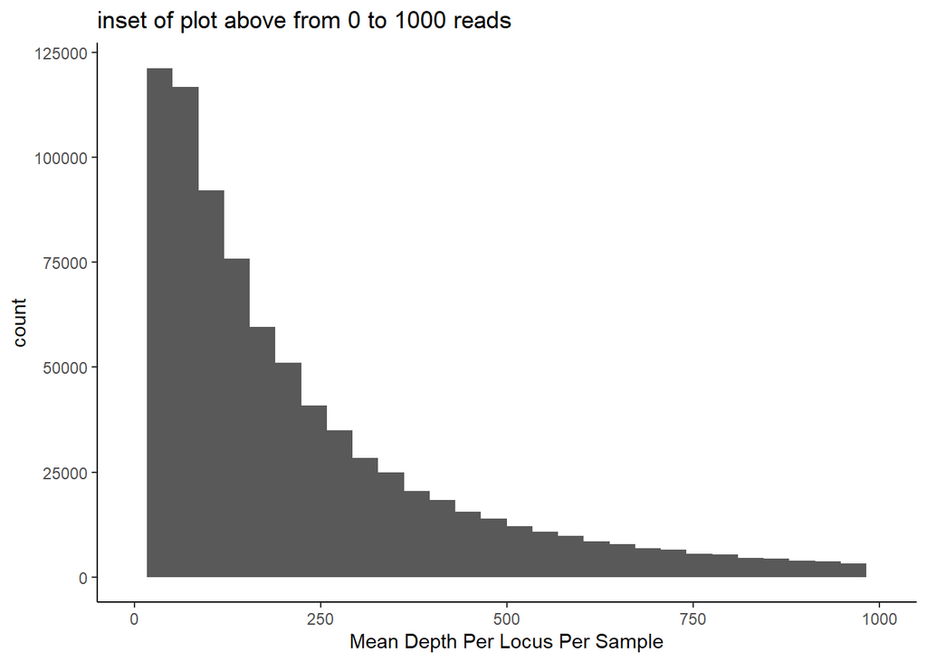

```r
marker_info %>%
  filter(marker %in% colnames(genos_2.0)) %>%
  filter(ind %in% genos_2.0$Sample) %>%
  mutate(sumdepth=a1_count+a2_count) %>%
  ggplot + aes(x=sumdepth)+geom_histogram()+theme_classic()+xlab("Mean Depth Per Locus Per Sample")+xlim(0,1000)+ggtitle("inset of plot above from 0 to 1000 reads")
```

Markers in the SFGL O. mykiss GT-seq panel are associated with varying phenotpyes (e.g., adult run-timing, temperature tolerance, etc.) and some are presumed to be neutral. Look at the distribution of marker types in the quality filtered dataset.

```r
##read in excel file with marker information##
marker_mapping <- readxl::read_xlsx("C:/Users/olsenk2/OneDrive - Oregon State University/Desktop/Omykiss_Siletz_2023/Omy_GTseq_panel/final_mapping_results.xlsx", sheet = 1)

##The Omy-5 Marker names in the mapping file differ from those in the genotype file. Adjust the names in the mapping file##
marker_mapping %<>%
  mutate(marker = case_when(str_detect(marker, "OmyR14589") ~ "OmyR14589Pearse",
                            str_detect(marker, "OmyR19198") ~ "OmyR19198Pearse",
                            str_detect(marker, "OmyR24370") ~ "OmyR24370Pearse",
                            str_detect(marker, "OmyR33562") ~ "OmyR33562Pearse",
                            str_detect(marker, "OmyR40252") ~ "OmyR40252Pearse",
                            str_detect(marker, "OmyR40319") ~ "OmyR40319Pearse",
                            TRUE ~ as.character(marker)

  ))

marker_summary <- marker_mapping %>%
  mutate(marker = str_replace(marker, "Omy(\\d+)", "Chr\\1")) %>% # convert names to match
  filter(marker %in% colnames(genos_2.0)) %>% # exclude filtered loci
  mutate(neutral = if_else(str_detect(`Presumed Type`, 'neutral|Neutral'), "neutral", "adaptive")) %>%
  mutate(run_timing = if_else(str_detect(`Presumed Type`, 'run|Run'), "run_timing", "non-run_timing")) %>%
  mutate(neutral = case_when(str_detect(marker, "OmyY1_2SEXY") ~ 'Sex_ID', ##Sex marker is classified as an adaptive marker. change to "Sex_ID"##
         TRUE ~ as.character(neutral))) %>%
  dplyr::select(marker, chr, start, 'Presumed Type', neutral, run_timing, Source)

kable(table(marker_summary$neutral), col.names = c("Type", "Frequency"))
```

| Type | Frequency |
| --- | --- |
| adaptive | 105 |
| neutral | 221 |
| Sex_ID | 1 |

Look at the number of adult run timing markers on chromsome 28 and the number of anadromous/resident markers on chromosome 5 within the 105 adaptive markers.

```r
##subset the adaptive markers##
adaptive_markers<-subset(marker_summary, marker_summary$neutral == "adaptive")

print(paste(length(which(adaptive_markers$`Presumed Type` == "Adaptive. Residency vs anadromy")), "Markers associated with anadromy/residency"))
```

```
## [1] "6 Markers associated with anadromy/residency"
```

```r
print(paste(length(which(adaptive_markers$run_timing == "run_timing")), "Markers associated with adult run timing"))
```

```
## [1] "12 Markers associated with adult run timing"
```

Save the quality fitlered dataset as R object for easy loading.

```r
save(genos_2.0, file = "C:/Users/olsenk2/OneDrive - Oregon State University/Desktop/Omy_klamath/Jan_2024_analyses/reproducible/O.mykiss_Klamath_Jan_2024_analyses_genos_2.0.R")
```